# Raji IVIS

L. Meuris

2026-04-08

# Description of experiments

Purpose of the experiment is to look at the effect of MGAT5 engineering in CART-cells in a mouse tumor model. The model uses Raji cells, which create blood tumors of the Burkitt’s lymphoma type. These cells are CD19, CD20 and CD70 positive.

The experiments have appr. the following timelines:

- day -1 or -2: weight baseline measurement
- day 0: injection of Raji cells IV
- day 4, 5 or 6: start of weight and IVIS measurements
- day: 7 CART cell injection
- around day 130: rechallenge if applicable

Careful; depending on the data source file, the days can be relative to injection of Raji cells, but also relative to the start of the CART cell engineering, which starts typically 6 days earlier. That means that the day of Raji injection would become day 6 and CART cell injection day 13.

The mice are followed up via body weight measurements and IVIS data, which measures luminescence of the Raji cells in the mice. There are several experiments:

Experiment 51:

- PBS: no cells given
- NTC: 4 million cells donor T-cells, no CAR T cells
- CD70 CART WT 4 million cells
- CD70 CART MGAT5 4 million cells
- CD70 CART WT 2 million cells
- CD70 CART MGAT5 2 million cells
- CD20 CART WT 1 million cells
- CD20 CART MGAT5 1 million cells
- CD20 CART WT 0.5 million cells
- CD20 CART MGAT5 0.5 million cells

Experiment 62 and 68:

- NTC: 4 million cells donor T-cells, no CAR T cells
- CD70 CART WT 4 million cells
- CD70 CART MGAT5 4 million cells
- CD20 CART WT 0.5 million cells
- CD20 CART MGAT5 0.5 million cells
- CD19 CART WT 2 million cells
- CD19 CART MGAT5 2 million cells

Experiment 74: used 6 mice per group, and no CD19 CART cells:

- NTC: 4 million cells donor T-cells, no CAR T cells
- CD70 CART WT 4 million cells
- CD70 CART MGAT5 4 million cells
- CD20 CART WT 0.5 million cells
- CD20 CART MGAT5 0.5 million cells

Experiment 91, 97 and 103:

- NTC
- CD19 CART WT
- CD19 CART MGAT5

Summarizing we can say that:

1. there are 3 CART targets: CD19, CD20, CD70
2. different amounts of CART cells have been injected; 0.5, 2 or 4 million
3. CART cells were either engineered or not to have MGAT5 knocked out

There was a rechallenge part to experiments 51 and 74 but not to 62, 68, 91 and 97. Exp 103 is still running. A rechallenge means that tumor cells were administered again after a set period. We also note the end-day of the experiments, as we need this for calculations of the survival times.

Note: for Exp 91, the IVIS machine was unavailable, so it was terminated prematurely. Note 2: in the analyses below, the CD20 data is not used. The metadata thus only contains info on the mice that are used.

```r
# These are days since tumor inoculation
day_rechallenge_E51 <- 133
day_rechallenge_E62 <- NA
day_rechallenge_E68 <- NA
day_rechallenge_E74 <- 139
day_rechallenge_E91 <- NA
day_rechallenge_E97 <- NA #26/3/26: in fact, there was a rechallenge, but ignored it since too little mice for plots and stats
day_rechallenge_E103 <- NA #26/3/26: exp still running, rechallenge may or may not happen

day_end_E51 <- 216
day_end_E62 <- 83
day_end_E68 <- 88
day_end_E74 <- 202
day_end_E91 <- 25
day_end_E97 <- 137 #26/3/26: did not end on day 137, but decided to use this as end date, since too few mice for rechallenge.
day_end_E103 <- 63 #26/3/26: exp still running, end date not final
```

# Data

First, we load all the data

```r
sheets <- excel_sheets(here('data/data_cleaned.xlsx'))
datalist <- map(sheets, read_xlsx, path = here('data/data_cleaned.xlsx'))
names(datalist) <- sheets
```

## Metadata

Get the metadata

```r
metadata <- datalist$Metadata
```

## IVIS data

```r
IVIS <- datalist[str_detect(names(datalist), 'IVIS')] %>% # select only IVIS data
  bind_rows(.id = 'Experiment') %>%
  mutate(Experiment = str_remove(Experiment, 'IVIS'),
         Mouse = as.numeric(Mouse),
         Day = Day_SinceTumorInoculation) %>%
  filter(!is.na(IVIS_Counts)) %>%
  filter(IVIS_Exposure == 3) %>%
  select(Experiment, Mouse, Day, IVIS_Counts) %>%
  arrange(Experiment, Mouse, Day)
IVIS <- left_join(IVIS, metadata)
```

Clean up

```r
rm(metadata, datalist, sheets)
```

# Data cleaning

Parse variables to correct type Remove some data that are superfluous or problematic:

EXP51: - Mouse 21 in exp 51 was a sentinel mouse

EXP62: - Mouse 26 and 27 in exp 62 were spare, were not used - Mouse 18, 23, 24, 25, 28 in exp 62 died from heat of the lamps so cannot be used in analysis

EXP68: - Mice 1, 22 were not in the experiment and 38-43 were backup in exp 68.

EXP74: - Mouse 22: euthanized due to unsure Raji injection - Mouse 30: euthanized by accident - Mouse 29: excluded due to unsure Raji injection - Mouse 46 and 47: controls for Raji effectiveness at secondary injection

```r
IVIS <- IVIS %>%
  filter(!(Mouse %in% c(18,23,24,25,26,27,28) & Experiment == 'E62')) %>%
  filter(!(Mouse == 21 & Experiment == 'E51')) %>%
  filter(!(Mouse %in% c(1,22,38,39,40,41,42,43) & Experiment == 'E68')) %>%
  filter(!(Mouse %in% c(22,29,30,46,47) & Experiment == 'E74')) %>%
  filter(!is.na(Treatment)) %>%
  filter(Dose %in% c(0,4) | is.na(Dose)) %>%
  arrange(Experiment, Mouse, Day) %>%
  mutate(Experiment = factor(Experiment, levels = c('E51', 'E62', 'E68', 'E74',
                                                    'E91', 'E97', 'E103')),
         ID = fct_inorder(paste0(Experiment, 'M', Mouse)),
         Treatment = factor(Treatment),
         Target = factor(Target, levels =c('Ctrl', 'CD19', 'CD20', 'CD70')),
         MGAT5 = factor(MGAT5, levels = c('Ctrl', 'MGAT5WT', 'MGAT5KO')),
         Day_Rechallenge = case_when(
           Experiment == 'E51' ~ day_rechallenge_E51,
           Experiment == 'E62' ~ day_rechallenge_E62,
           Experiment == 'E68' ~ day_rechallenge_E68,
           Experiment == 'E74' ~ day_rechallenge_E74,
           Experiment == 'E91' ~ day_rechallenge_E91,
           Experiment == 'E97' ~ day_rechallenge_E97,
           Experiment == 'E103' ~ day_rechallenge_E103),
         Day_End = case_when(
           Experiment == 'E51' ~ day_end_E51,
           Experiment == 'E62' ~ day_end_E62,
           Experiment == 'E68' ~ day_end_E68,
           Experiment == 'E74' ~ day_end_E74,
           Experiment == 'E91' ~ day_end_E91,
           Experiment == 'E97' ~ day_end_E97,
           Experiment == 'E103' ~ day_end_E103),
         Day_SinceTumorInoculation = Day,
         Day_SinceTCellIsolation = Day + 6) %>%
  select(Experiment, Mouse, ID, everything())
```

Write datasheets to xlsx files for later reference

```r
#IVIS %>% writexl::write_xlsx(here('output/IVIS.xlsx'))
```

Some data QC

```r
#IVIS %>% map(~any(is.na(.)))
```

# Plot IVIS data

IVIS traces for individual mice per experiment

## CD70

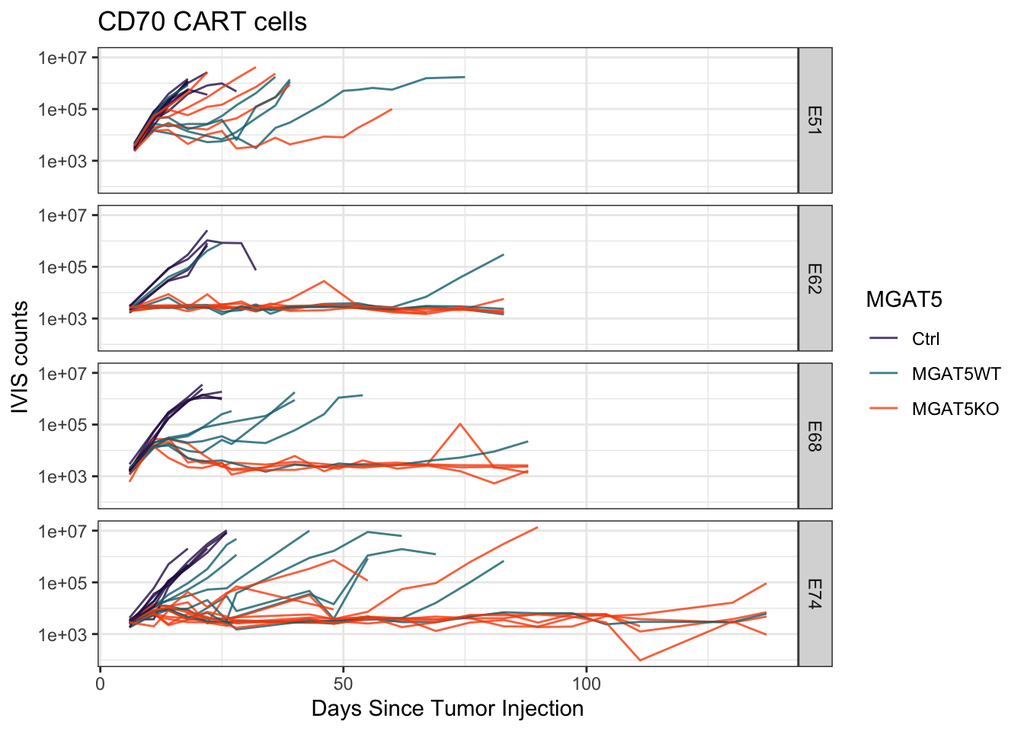

```r
IVIS_70 <- IVIS %>%
  filter(Target %in% c('Ctrl', 'CD70')) %>%
  filter(Experiment %in% c('E51', 'E62','E68', 'E74')) %>%
  filter(Day <= Day_Rechallenge | is.na(Day_Rechallenge)) %>%
  droplevels %>%
  ggplot(aes(x = Day, y = IVIS_Counts, Group = ID, color = MGAT5)) +
  geom_line(alpha = 0.8) +
  facet_grid(Experiment~.) +
  theme_bw() +
  scale_y_log10() +
  scale_color_manual(values = c(
    rgb(44,20,83, maxColorValue = 255),
    rgb(14,111,124, maxColorValue = 255),
    rgb(251,79,6, maxColorValue = 255))) +
  ylab('IVIS counts') +
  xlab('Days Since Tumor Injection') +
  ggtitle('CD70 CART cells')

IVIS_70
```

```r
ggsave(here('output/IVISPlot_CD70_Raji_perExp.pdf'), IVIS_70,
       device = 'pdf', width  = 8, height = 5)
```

## CD19

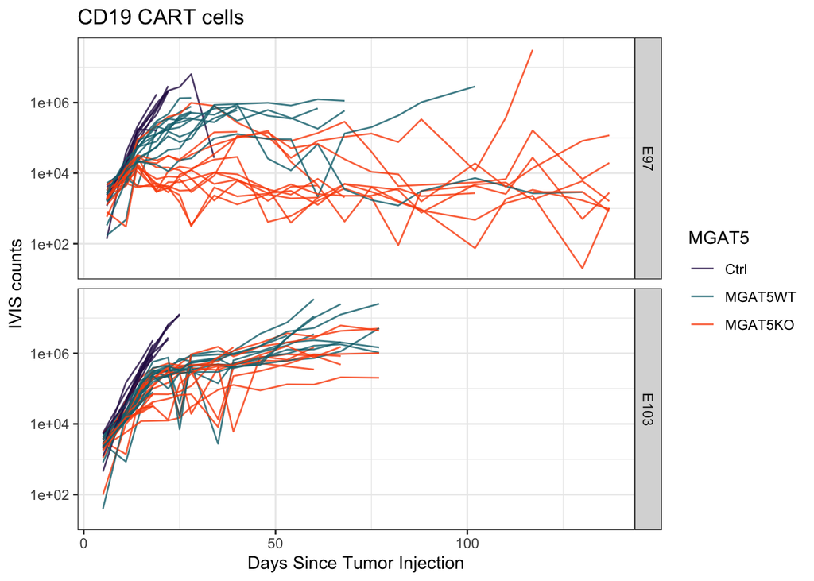

```r
IVIS_19 <- IVIS %>%
  filter(Target %in% c('Ctrl', 'CD19')) %>%
  filter(Experiment %in% c('E91', 'E97','E103')) %>%
  filter(Day <= Day_Rechallenge | is.na(Day_Rechallenge)) %>%
  droplevels %>%
  ggplot(aes(x = Day, y = IVIS_Counts, Group = ID, color = MGAT5)) +
  geom_line(alpha = 0.8) +
  facet_grid(Experiment~.) +
  theme_bw() +
  scale_y_log10() +
  scale_color_manual(values = c(
    rgb(44,20,83, maxColorValue = 255),
    rgb(14,111,124, maxColorValue = 255),
    rgb(251,79,6, maxColorValue = 255))) +
  ylab('IVIS counts') +
  xlab('Days Since Tumor Injection') +
  ggtitle('CD19 CART cells')

IVIS_19
```

```r
ggsave(here('output/IVISPlot_CD19_Raji_perExp.pdf'), IVIS_19,
       device = 'pdf', width  = 8, height = 5)
```